# 05 · Capstone — a guided microbiome analysis in R

Trends in multi-omics data analysis for Microbial Ecology and Biotechnology — UFZ Leipzig

Instructor: Anderson Santos

R refresher session

## The scenario

You have received a human-gut microbiome study — three tables: **abundances** (1,006 samples × 130 genera), a **taxonomy**, and **participant metadata**. Your job: take it from raw tables to a few defensible conclusions, combining everything from lessons 01–04.

## How this notebook works

It is a **hands-on activity**, not a lecture. Each **step** states a task and gives hints; you write the code in the blank chunk. A **collapsible solution** sits under each step — try first, peek if stuck. Steps build on each other, so run them in order.

> Suggested time: 45–60 min. Steps 1–7 are core; 8–10 are extension.

> **Instructor note.** Run as pair-programming: one drives, one navigates. Reveal each solution only after most pairs have attempted the step.

## Step 0 · Setup — load packages and data (just run it)

```r
library(readr); library(dplyr); library(tidyr)          # import + wrangle
library(ggplot2); library(forcats); library(stringr)    # plot + factors + text
library(vegan)     # community ecology toolkit: diversity() and ordination (metaMDS)

# Locate and load the three tables (same pattern used in every lesson).
data_dir <- if (file.exists("../data/sample_metadata.csv")) "../data" else "data"
meta     <- read_csv(file.path(data_dir, "sample_metadata.csv"))
taxonomy <- read_csv(file.path(data_dir, "taxonomy.csv"))
abund    <- read_csv(file.path(data_dir, "genus_abundance.csv"))

# cat() prints a quick shape report so we can confirm the loads worked.
cat("metadata :", nrow(meta), "x", ncol(meta), "\n")
```

```
#> metadata : 1006 x 7
```

```r
cat("taxonomy :", nrow(taxonomy), "x", ncol(taxonomy), "\n")
```

```
#> taxonomy : 130 x 3
```

```r
cat("abundance:", nrow(abund), "x", ncol(abund), "\n")
```

```
#> abundance: 1006 x 131
```

## Step 1 · Clean the metadata

**Task.** Real data is messy. (a) Report how many rows have a missing `age` and how many have a missing `sex`. (b) Make an analysis-ready copy `meta_clean` that keeps only rows with a known `age` **and** known `bmi_group`, and set `bmi_group` as an **ordered factor** (underweight → morbidly obese).

*Hints:* `is.na()`, `sum()`, `filter()`, `factor(..., levels = ...)`.

```r
# Your code here
```

**Solution: Step 1**

```r
# is.na() flags missing values; sum() counts the TRUEs -> how many gaps in each column.
cat("missing age:", sum(is.na(meta$age)),
    " | missing sex:", sum(is.na(meta$sex)), "\n")
```

```
#> missing age: 56  | missing sex: 37
```

```r
bmi_levels <- c("underweight","lean","overweight","obese","severeobese","morbidobese")
meta_clean <- meta |>
  filter(!is.na(age), !is.na(bmi_group)) |>              # keep only fully-labelled samples
  mutate(bmi_group = factor(bmi_group, levels = bmi_levels))  # + set the clinical order

cat("kept", nrow(meta_clean), "of", nrow(meta), "samples\n")  # show the cost of missing data
```

```
#> kept 900 of 1006 samples
```

## Step 2 · Reshape abundances to tidy long form

**Task.** Turn the wide `abund` table (one column per genus) into a **long** table `ab_long` with columns `sample_id`, `genus`, `abundance`. Report its number of rows and confirm it equals samples × genera.

*Hints:* `pivot_longer(-sample_id, names_to = ..., values_to = ...)`.

```r
# Your code here
```

**Solution: Step 2**

```r
# pivot_longer stacks the 130 genus columns into two: 'genus' (name) + 'abundance' (value).
ab_long <- abund |>
  pivot_longer(-sample_id, names_to = "genus", values_to = "abundance")
# Sanity check: rows should equal samples x genera (ncol - 1 drops the sample_id column).
cat(nrow(ab_long), "rows =", nrow(abund), "samples x", ncol(abund) - 1, "genera\n")
```

```
#> 130780 rows = 1006 samples x 130 genera
```

## Step 3 · Join taxonomy and metadata

**Task.** Build one tidy table `ab_full` = `ab_long` + phylum/family (from `taxonomy`, by `genus`) + region/BMI/age (from `meta_clean`, by `sample_id`). Because `meta_clean` dropped some samples, keep only rows that have metadata (`inner_join`, or drop `NA` region).

*Hints:* `left_join()` / `inner_join()` on the shared keys.

```r
# Your code here
```

**Solution: Step 3**

```r
ab_full <- ab_long |>
  left_join(taxonomy, by = "genus") |>                    # add phylum/family per genus
  # inner_join keeps only rows that match on both sides -> drops samples cleaned away.
  inner_join(select(meta_clean, sample_id, nationality, bmi_group, age),
             by = "sample_id")
glimpse(ab_full)
```

```
#> Rows: 117,000
#> Columns: 8
#> $ sample_id   <chr> "Sample-1", "Sample-1", "Sample-1", "Sample-1", "Sample-1"…
#> $ genus       <chr> "Actinomycetaceae", "Aerococcus", "Aeromonas", "Akkermansi…
#> $ abundance   <dbl> 0, 0, 0, 21, 1, 72, 0, 0, 176, 10, 9, 0, 0, 0, 0, 1, 67, 2…
#> $ phylum      <chr> "Actinobacteria", "Firmicutes", "Proteobacteria", "Verruco…
#> $ family      <chr> "Actinobacteria", "Bacilli", "Proteobacteria", "Verrucomic…
#> $ nationality <chr> "US", "US", "US", "US", "US", "US", "US", "US", "US", "US"…
#> $ bmi_group   <fct> severeobese, severeobese, severeobese, severeobese, severe…
#> $ age         <dbl> 28, 28, 28, 28, 28, 28, 28, 28, 28, 28, 28, 28, 28, 28, 28…
```

## Step 4 · Alpha diversity per sample (compute it yourself)

**Task.** For every sample compute (a) **observed richness** (number of genera with abundance > 0) and (b) the **Shannon index** on the abundances. Put them in `alpha`, then join `meta_clean` and report the **mean of each metric per region**.

*Hints:* group `ab_full` by `sample_id`; richness = `sum(abundance > 0)`; Shannon = `diversity(abundance, index = "shannon")` from **vegan** (feed it the per-sample abundance vector), or compute by hand.

```r
# Your code here
```

**Solution: Step 4**

```r
# Group by sample (carrying its metadata) so summarise() gives one diversity row per sample.
alpha <- ab_full |>
  group_by(sample_id, nationality, bmi_group, age) |>
  summarise(
    richness = sum(abundance > 0),                       # count genera present (abundance > 0)
    shannon  = diversity(abundance, index = "shannon"),  # vegan's Shannon index on the vector
    .groups  = "drop")

# Then average each metric per region to compare communities.
alpha |>
  group_by(nationality) |>
  summarise(mean_richness = mean(richness),
            mean_shannon  = mean(shannon),
            n = n()) |>                                  # n() = samples per region
  arrange(desc(mean_shannon))                            # most diverse region first
```

| nationality | mean_richness | mean_shannon | n |
| --- | --- | --- | --- |
| EasternEurope | 106.0000 | 3.381606 | 1 |
| Scandinavia | 103.6233 | 3.170034 | 146 |
| UKIE | 102.8500 | 3.129606 | 40 |
| SouthEurope | 102.5465 | 3.083114 | 86 |
| NA | 109.3333 | 3.024938 | 9 |
| CentralEurope | 102.2534 | 2.907922 | 584 |
| US | 100.5000 | 2.864107 | 34 |

## Step 5 · A diversity figure

**Task.** Make a **boxplot** of `shannon` across `bmi_group` (from `alpha`), filled by BMI group, with clear labels and no redundant legend. Bonus: overlay faint jittered points.

*Hints:* `geom_boxplot()`, `geom_jitter(alpha = ...)`, `labs()`, `theme(legend.position = "none")`.

```r
# Your code here
```

**Solution: Step 5**

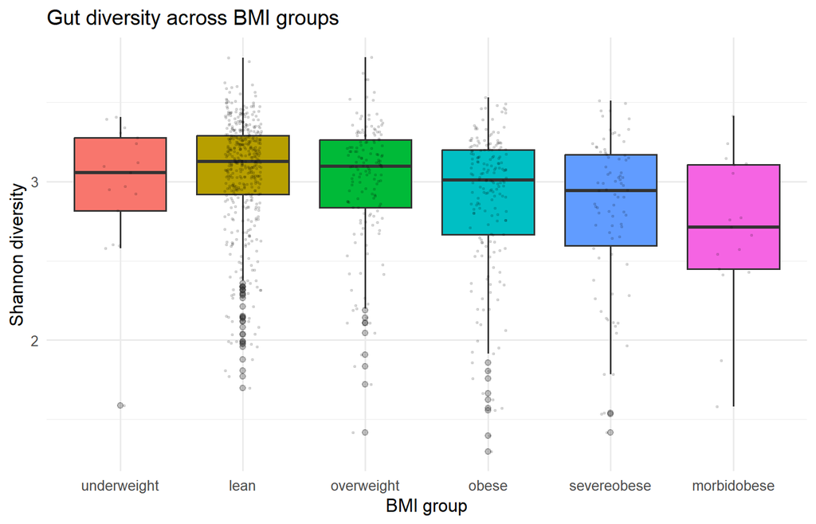

```r
ggplot(alpha, aes(bmi_group, shannon, fill = bmi_group)) +  # category (x) vs number (y)
  geom_boxplot(outlier.alpha = 0.3) +                       # median + quartiles per BMI group
  geom_jitter(width = 0.15, alpha = 0.1, size = 0.4) +      # faint raw points show sample sizes
  labs(title = "Gut diversity across BMI groups",
       x = "BMI group", y = "Shannon diversity") +
  theme_minimal() + theme(legend.position = "none")         # x already labels groups -> no legend
```

## Step 6 · Taxonomic composition per region

**Task.** Compute the **mean relative abundance of each phylum per region** and draw a **stacked bar chart** (y as %). Name the dominant phylum in each region.

*Hints:* per sample → per-phylum sum → divide by the sample total → average per region; `geom_col()`, `scale_y_continuous(labels = scales::percent)`.

```r
# Your code here
```

**Solution: Step 6**

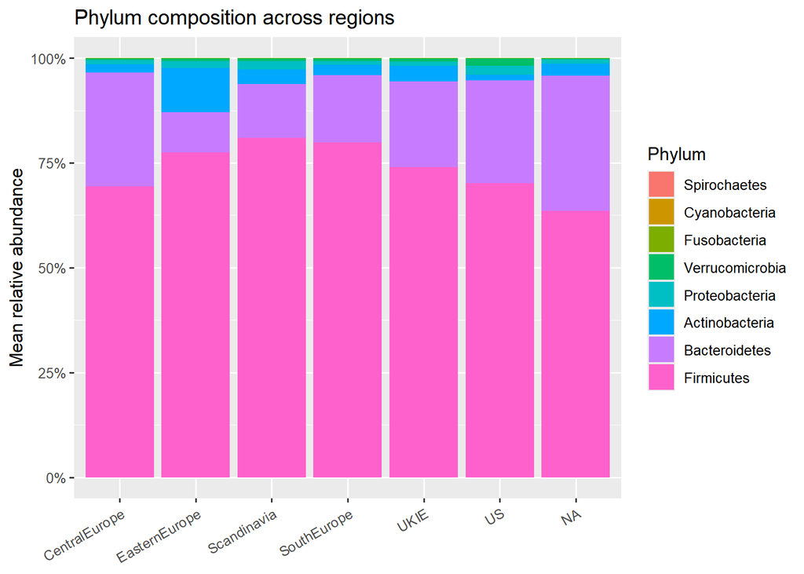

```r
# Three-stage split-apply-combine: per-phylum sum -> per-sample share -> region mean.
composition <- ab_full |>
  group_by(sample_id, nationality, phylum) |>
  summarise(phy = sum(abundance), .groups = "drop") |>  # total abundance per phylum in a sample
  group_by(sample_id) |>
  mutate(rel = phy / sum(phy)) |>                       # divide by sample total -> proportion
  group_by(nationality, phylum) |>
  summarise(mean_rel = mean(rel), .groups = "drop")     # average that share per region

ggplot(composition, aes(nationality, mean_rel,
                        fill = fct_reorder(phylum, mean_rel, sum))) +  # order the stack by size
  geom_col() +                                          # stacks automatically (fill varies)
  scale_y_continuous(labels = scales::percent) +        # y axis as %
  labs(title = "Phylum composition across regions",
       x = NULL, y = "Mean relative abundance", fill = "Phylum") +
  theme(axis.text.x = element_text(angle = 30, hjust = 1))  # tilt long region labels
```

```r
# slice_max keeps the single top-ranked phylum within each region group:
composition |> group_by(nationality) |> slice_max(mean_rel, n = 1)
```

| nationality | phylum | mean_rel |
| --- | --- | --- |
| CentralEurope | Firmicutes | 0.6934257 |
| EasternEurope | Firmicutes | 0.7751947 |
| Scandinavia | Firmicutes | 0.8092692 |
| SouthEurope | Firmicutes | 0.7988716 |
| UKIE | Firmicutes | 0.7394846 |
| US | Firmicutes | 0.7008404 |
| NA | Firmicutes | 0.6353943 |

## Step 7 · A simple statistic — does diversity differ by BMI?

**Task.** Test whether Shannon diversity differs across BMI groups. Use a **one-way ANOVA** (`aov`) of `shannon ~ bmi_group` on `alpha`, and report the p-value. State in one sentence whether there is evidence of a difference.

*Hints:* `fit <- aov(shannon ~ bmi_group, data = alpha)`; `summary(fit)`.

```r
# Your code here
```

**Solution: Step 7**

```r
fit <- aov(shannon ~ bmi_group, data = alpha)
summary(fit)
```

```
#>              Df Sum Sq Mean Sq F value   Pr(>F)
#> bmi_group     5   7.79  1.5584   9.463 8.33e-09 ***
#> Residuals   894 147.22  0.1647
#> ---
#> Signif. codes:  0 '***' 0.001 '**' 0.01 '*' 0.05 '.' 0.1 ' ' 1
```

```r
# The p-value (Pr(>F)) tells you whether mean diversity differs across BMI
# groups. Interpret it in plain words for the class; pair it with the Step 5 boxplot.
```